# Predict Bike Sharing Demand with AutoGluon Template

## Project: Predict Bike Sharing Demand with AutoGluon

This notebook is a template with each step that you need to complete for the project.

Please fill in your code where there are explicit `?` markers in the notebook. You are welcome to add more cells and code as you see fit.

Once you have completed all the code implementations, please export your notebook as a HTML file so the reviews can view your code. Make sure you have all outputs correctly outputted.

`File-> Export Notebook As... -> Export Notebook as HTML`

There is a writeup to complete as well after all code implememtation is done. Please answer all questions and attach the necessary tables and charts. You can complete the writeup in either markdown or PDF.

Completing the code template and writeup template will cover all of the rubric points for this project.

The rubric contains "Stand Out Suggestions" for enhancing the project beyond the minimum requirements. The stand out suggestions are optional. If you decide to pursue the "stand out suggestions", you can include the code in this notebook and also discuss the results in the writeup file.

## Step 1: Create an account with Kaggle

### Create Kaggle Account and download API key

Below is example of steps to get the API username and key. Each student will have their own username and key.

1. Open account settings.

[figure not shown]

[figure not shown]

2. Scroll down to API and click Create New API Token.

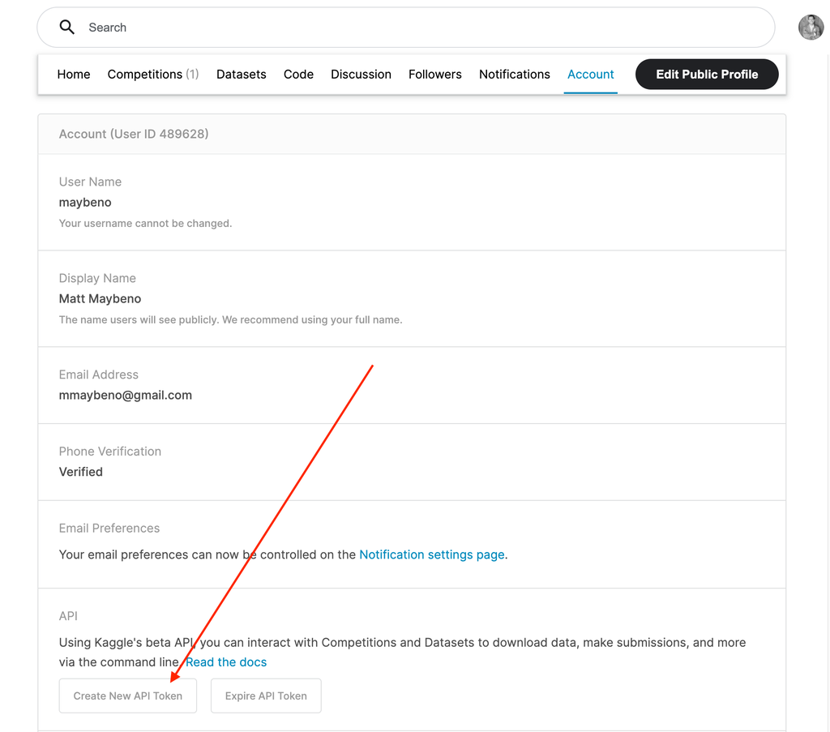

[figure not shown]

3. Open up `kaggle.json` and use the username and key.

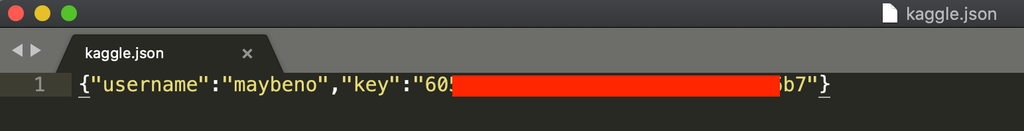

## Step 2: Download the Kaggle dataset using the kaggle python library

### Open up Sagemaker Studio and use starter template

1. Notebook should be using a `ml.t3.medium` instance (2 vCPU + 4 GiB)
2. Notebook should be using kernal: `Python 3 (MXNet 1.8 Python 3.7 CPU Optimized)`

### Install packages

```python
!pip install -U pip
!pip install -U setuptools wheel
!pip install -U "mxnet<2.0.0" bokeh==2.0.1
!pip install autogluon --no-cache-dir
# Without --no-cache-dir, smaller aws instances may have trouble installing
```

[output not shown]

[output cut: 45 more lines]

[output not shown]

### Setup Kaggle API Key

```python
# create the .kaggle directory and an empty kaggle.json file
!mkdir -p /root/.kaggle
!touch /root/.kaggle/kaggle.json
!chmod 600 /root/.kaggle/kaggle.json
```

```python
# Fill in your user name and key from creating the kaggle account and API token file
import json
kaggle_username = "ishanp94"
kaggle_key = "668bd7d637492467eff7e7e63989169d"

# Save API token the kaggle.json file
with open("/root/.kaggle/kaggle.json", "w") as f:
    f.write(json.dumps({"username": kaggle_username, "key": kaggle_key}))
```

### Download and explore dataset

### Go to the bike sharing demand competition and agree to the terms

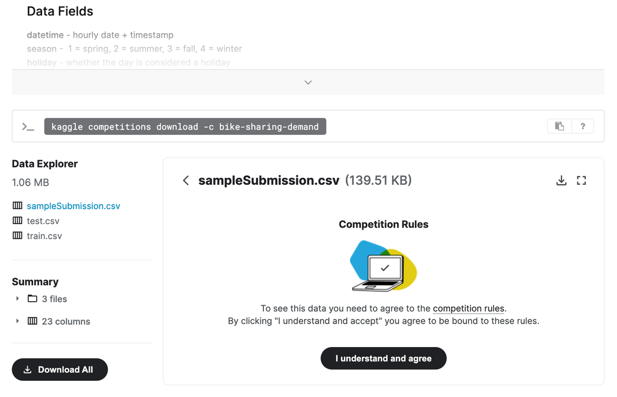

```python
# Download the dataset, it will be in a .zip file so you'll need to unzip it as well.
!kaggle competitions download -c bike-sharing-demand
# If you already downloaded it you can use the -o command to overwrite the file
!unzip -o bike-sharing-demand.zip
```

```
bike-sharing-demand.zip: Skipping, found more recently modified local copy (use --force to force download)
Archive:  bike-sharing-demand.zip
  inflating: sampleSubmission.csv
  inflating: test.csv
  inflating: train.csv
```

```python
import pandas as pd
from autogluon.tabular import TabularPredictor
```

```python
# Create the train dataset in pandas by reading the csv
# Set the parsing of the datetime column so you can use some of the `dt` features in pandas later
train = pd.read_csv('train.csv', parse_dates=['datetime'])
train.head()
```

|  | datetime | season | holiday | workingday | weather | temp | atemp | humidity | windspeed | casual | registered | count |
| --- | --- | --- | --- | --- | --- | --- | --- | --- | --- | --- | --- | --- |
| 0 | 2011-01-01 00:00:00 | 1 | 0 | 0 | 1 | 9.84 | 14.395 | 81 | 0.0 | 3 | 13 | 16 |
| 1 | 2011-01-01 01:00:00 | 1 | 0 | 0 | 1 | 9.02 | 13.635 | 80 | 0.0 | 8 | 32 | 40 |
| 2 | 2011-01-01 02:00:00 | 1 | 0 | 0 | 1 | 9.02 | 13.635 | 80 | 0.0 | 5 | 27 | 32 |
| 3 | 2011-01-01 03:00:00 | 1 | 0 | 0 | 1 | 9.84 | 14.395 | 75 | 0.0 | 3 | 10 | 13 |
| 4 | 2011-01-01 04:00:00 | 1 | 0 | 0 | 1 | 9.84 | 14.395 | 75 | 0.0 | 0 | 1 | 1 |

```python
# Simple output of the train dataset to view some of the min/max/varition of the dataset features.
train.describe()
```

|  | season | holiday | workingday | weather | temp | atemp | humidity | windspeed | casual | registered | count |
| --- | --- | --- | --- | --- | --- | --- | --- | --- | --- | --- | --- |
| count | 10886.000000 | 10886.000000 | 10886.000000 | 10886.000000 | 10886.00000 | 10886.000000 | 10886.000000 | 10886.000000 | 10886.000000 | 10886.000000 | 10886.000000 |
| mean | 2.506614 | 0.028569 | 0.680875 | 1.418427 | 20.23086 | 23.655084 | 61.886460 | 12.799395 | 36.021955 | 155.552177 | 191.574132 |
| std | 1.116174 | 0.166599 | 0.466159 | 0.633839 | 7.79159 | 8.474601 | 19.245033 | 8.164537 | 49.960477 | 151.039033 | 181.144454 |
| min | 1.000000 | 0.000000 | 0.000000 | 1.000000 | 0.82000 | 0.760000 | 0.000000 | 0.000000 | 0.000000 | 0.000000 | 1.000000 |
| 25% | 2.000000 | 0.000000 | 0.000000 | 1.000000 | 13.94000 | 16.665000 | 47.000000 | 7.001500 | 4.000000 | 36.000000 | 42.000000 |
| 50% | 3.000000 | 0.000000 | 1.000000 | 1.000000 | 20.50000 | 24.240000 | 62.000000 | 12.998000 | 17.000000 | 118.000000 | 145.000000 |
| 75% | 4.000000 | 0.000000 | 1.000000 | 2.000000 | 26.24000 | 31.060000 | 77.000000 | 16.997900 | 49.000000 | 222.000000 | 284.000000 |
| max | 4.000000 | 1.000000 | 1.000000 | 4.000000 | 41.00000 | 45.455000 | 100.000000 | 56.996900 | 367.000000 | 886.000000 | 977.000000 |

```python
# Create the test pandas dataframe in pandas by reading the csv, remember to parse the datetime!
test = pd.read_csv('test.csv', parse_dates=['datetime'])
test.head()
```

|  | datetime | season | holiday | workingday | weather | temp | atemp | humidity | windspeed |
| --- | --- | --- | --- | --- | --- | --- | --- | --- | --- |
| 0 | 2011-01-20 00:00:00 | 1 | 0 | 1 | 1 | 10.66 | 11.365 | 56 | 26.0027 |
| 1 | 2011-01-20 01:00:00 | 1 | 0 | 1 | 1 | 10.66 | 13.635 | 56 | 0.0000 |
| 2 | 2011-01-20 02:00:00 | 1 | 0 | 1 | 1 | 10.66 | 13.635 | 56 | 0.0000 |
| 3 | 2011-01-20 03:00:00 | 1 | 0 | 1 | 1 | 10.66 | 12.880 | 56 | 11.0014 |
| 4 | 2011-01-20 04:00:00 | 1 | 0 | 1 | 1 | 10.66 | 12.880 | 56 | 11.0014 |

```python
# Same thing as train and test dataset
submission = pd.read_csv('sampleSubmission.csv', parse_dates=['datetime'])
submission.head()
```

|  | datetime | count |
| --- | --- | --- |
| 0 | 2011-01-20 00:00:00 | 0 |
| 1 | 2011-01-20 01:00:00 | 0 |
| 2 | 2011-01-20 02:00:00 | 0 |
| 3 | 2011-01-20 03:00:00 | 0 |
| 4 | 2011-01-20 04:00:00 | 0 |

## Step 3: Train a model using AutoGluon’s Tabular Prediction

Requirements:

- We are prediting `count`, so it is the label we are setting.
- Ignore `casual` and `registered` columns as they are also not present in the test dataset.
- Use the `root_mean_squared_error` as the metric to use for evaluation.
- Set a time limit of 10 minutes (600 seconds).
- Use the preset `best_quality` to focus on creating the best model.

```python
cols_to_use = [x for x in train.columns if x not in ['casual','registered']]
predictor = TabularPredictor(label = 'count', eval_metric = 'root_mean_squared_error').fit(train_data = train[cols_to_use],time_limit = 60*10 ,presets = "best_quality")
```

[output not shown]

```
[1000]	train_set's rmse: 123.806	valid_set's rmse: 134.369
[2000]	train_set's rmse: 117.412	valid_set's rmse: 133.705
```

```
[1000]	train_set's rmse: 123.42	valid_set's rmse: 141.5
```

```
[1000]	train_set's rmse: 125.097	valid_set's rmse: 128.797
[2000]	train_set's rmse: 119.003	valid_set's rmse: 127.909
[3000]	train_set's rmse: 114.63	valid_set's rmse: 127.431
[4000]	train_set's rmse: 111.295	valid_set's rmse: 126.943
[5000]	train_set's rmse: 108.576	valid_set's rmse: 126.844
[6000]	train_set's rmse: 106.085	valid_set's rmse: 126.71
```

```
[1000]	train_set's rmse: 124.131	valid_set's rmse: 138.303
[2000]	train_set's rmse: 117.833	valid_set's rmse: 137.535
```

```
[1000]	train_set's rmse: 124.871	valid_set's rmse: 128.052
[2000]	train_set's rmse: 118.547	valid_set's rmse: 127.003
[3000]	train_set's rmse: 114.124	valid_set's rmse: 126.834
[4000]	train_set's rmse: 110.645	valid_set's rmse: 126.694
```

```
[1000]	train_set's rmse: 124.654	valid_set's rmse: 135.095
[2000]	train_set's rmse: 118.764	valid_set's rmse: 133.849
[3000]	train_set's rmse: 114.615	valid_set's rmse: 133.509
[4000]	train_set's rmse: 111.249	valid_set's rmse: 133.472
[5000]	train_set's rmse: 108.455	valid_set's rmse: 133.281
```

```
[1000]	train_set's rmse: 124.01	valid_set's rmse: 139.355
[2000]	train_set's rmse: 117.819	valid_set's rmse: 138.312
[3000]	train_set's rmse: 113.4	valid_set's rmse: 137.886
[4000]	train_set's rmse: 110.032	valid_set's rmse: 137.758
```

```
[1000]	train_set's rmse: 124.47	valid_set's rmse: 135.412
```

```
[1000]	train_set's rmse: 124.18	valid_set's rmse: 137.579
[2000]	train_set's rmse: 117.782	valid_set's rmse: 136.664
[3000]	train_set's rmse: 113.447	valid_set's rmse: 136.246
[4000]	train_set's rmse: 109.982	valid_set's rmse: 136.227
```

```
[1000]	train_set's rmse: 124.641	valid_set's rmse: 132.484
```

```
	-134.0883	 = Validation score   (root_mean_squared_error)
	46.45s	 = Training   runtime
	2.37s	 = Validation runtime
Fitting model: LightGBM_BAG_L1 ... Training model for up to 343.94s of the 543.95s of remaining time.
```

```
[1000]	train_set's rmse: 96.0217	valid_set's rmse: 123.249
```

```
[1000]	train_set's rmse: 94.7479	valid_set's rmse: 135.635
```

```
[1000]	train_set's rmse: 95.3055	valid_set's rmse: 132.087
```

```
[1000]	train_set's rmse: 95.1635	valid_set's rmse: 131.521
```

[output not shown]

[output cut: 80 more lines]

```
	Ran out of time, stopping training early. (Stopping on epoch 28)
	-115.2783	 = Validation score   (root_mean_squared_error)
	101.25s	 = Training   runtime
	0.33s	 = Validation runtime
Fitting model: XGBoost_BAG_L2 ... Training model for up to 9.96s of the 9.94s of remaining time.
	-117.3149	 = Validation score   (root_mean_squared_error)
	9.03s	 = Training   runtime
	0.08s	 = Validation runtime
Completed 1/20 k-fold bagging repeats ...
Fitting model: WeightedEnsemble_L3 ... Training model for up to 360.0s of the -0.11s of remaining time.
	-114.6099	 = Validation score   (root_mean_squared_error)
	0.36s	 = Training   runtime
	0.0s	 = Validation runtime
AutoGluon training complete, total runtime = 600.72s ...
TabularPredictor saved. To load, use: predictor = TabularPredictor.load("AutogluonModels/ag-20220223_062841/")
```

### Review AutoGluon's training run with ranking of models that did the best.

```
*** Summary of fit() ***
Estimated performance of each model:
                     model   score_val  pred_time_val    fit_time  pred_time_val_marginal  fit_time_marginal  stack_level  can_infer  fit_order
0      WeightedEnsemble_L3 -114.609851       6.968873  507.337767                0.000718           0.363719            3       True         19
1   NeuralNetFastAI_BAG_L2 -115.278299       6.145776  472.921942                0.328615         101.246418            2       True         17
2        LightGBMXT_BAG_L2 -116.270151       6.025136  382.324846                0.207975          10.649321            2       True         12
3          CatBoost_BAG_L2 -116.603221       5.853017  400.027687                0.035856          28.352162            2       True         15
4          LightGBM_BAG_L2 -116.772267       5.907119  379.696429                0.089958           8.020904            2       True         13
5           XGBoost_BAG_L2 -117.314945       5.895917  380.708661                0.078757           9.033137            2       True         18
6     ExtraTreesMSE_BAG_L2 -117.632320       6.262850  378.024268                0.445689           6.348743            2       True         16
7      WeightedEnsemble_L2 -118.423743       1.914344  128.183571                0.000650           0.490949            2       True         11
8   RandomForestMSE_BAG_L1 -118.456660       0.381701    6.949700                0.381701           6.949700            1       True          5
9   RandomForestMSE_BAG_L2 -119.479497       6.279829  400.662276                0.462668          28.986751            2       True         14
10    ExtraTreesMSE_BAG_L1 -128.733445       0.375690    3.131522                0.375690           3.131522            1       True          7
11         LightGBM_BAG_L1 -132.286410       0.480850   13.040467                0.480850          13.040467            1       True          4
12          XGBoost_BAG_L1 -132.308522       0.141713   14.752577                0.141713          14.752577            1       True          9
13         CatBoost_BAG_L1 -132.349692       0.044550   55.177902                0.044550          55.177902            1       True          6
14       LightGBMXT_BAG_L1 -134.088334       2.372641   46.446013                2.372641          46.446013            1       True          3
15  NeuralNetFastAI_BAG_L1 -137.993215       0.280157  111.377867                0.280157         111.377867            1       True          8
16   NeuralNetMXNet_BAG_L1 -143.349581       1.531994  120.742923                1.531994         120.742923            1       True         10
17   KNeighborsUnif_BAG_L1 -160.413078       0.103594    0.035970                0.103594           0.035970            1       True          1
18   KNeighborsDist_BAG_L1 -169.552096       0.104272    0.020584                0.104272           0.020584            1       True          2
Number of models trained: 19
Types of models trained:
{'StackerEnsembleModel_RF', 'StackerEnsembleModel_KNN', 'WeightedEnsembleModel', 'StackerEnsembleModel_XT', 'StackerEnsembleModel_CatBoost', 'StackerEnsembleModel_TabularNeuralNet', 'StackerEnsembleModel_LGB', 'StackerEnsembleModel_XGBoost', 'StackerEnsembleModel_NNFastAiTabular'}
Bagging used: True  (with 10 folds)
Multi-layer stack-ensembling used: True  (with 3 levels)
Feature Metadata (Processed):
(raw dtype, special dtypes):
('float', [])                : 3 | ['temp', 'atemp', 'windspeed']
('int', [])                  : 3 | ['season', 'weather', 'humidity']
('int', ['bool'])            : 2 | ['holiday', 'workingday']
('int', ['datetime_as_int']) : 1 | ['datetime']
Plot summary of models saved to file: AutogluonModels/ag-20220223_062841/SummaryOfModels.html
*** End of fit() summary ***
```

```
'WeightedEnsemble_L3'
```

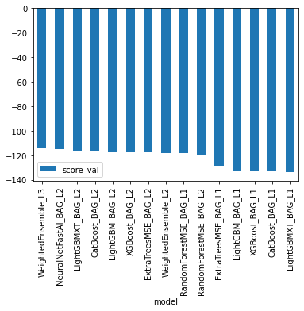

```python
predictor.fit_summary()
predictor.leaderboard(silent = True).head(15).plot(kind = 'bar', x = 'model', y = 'score_val')
predictor.get_model_best()
```

### Create predictions from test dataset

```python
predictions = predictor.predict(test)
predictions.head()
```

```
0     97.988815
1     90.987831
2     90.989319
3    110.624702
4    110.510269
Name: count, dtype: float32
```

#### NOTE: Kaggle will reject the submission if we don't set everything to be > 0.

```python
# Describe the `predictions` series to see if there are any negative values
predictions.describe()
```

```
count    6493.000000
mean      211.612076
std       130.960983
min       -20.903080
25%       104.787498
50%       194.801361
75%       300.254517
max       659.771912
Name: count, dtype: float64
```

```python
# How many negative values do we have?
sum(predictions<0)
```

```
2
```

```python
# Set them to zero
predictions[predictions < 0] = 0
```

### Set predictions to submission dataframe, save, and submit

```python
submission["count"] = predictions
submission.to_csv("submission.csv", index=False)
```

```python
!kaggle competitions submit -c bike-sharing-demand -f submission.csv -m "first raw submission"
```

```
Successfully submitted to Bike Sharing Demand
```

#### View submission via the command line or in the web browser under the competition's page - `My Submissions`

```python
!kaggle competitions submissions -c bike-sharing-demand | tail -n +1 | head -n 6
```

```
fileName                     date                 description                                 status    publicScore  privateScore
---------------------------  -------------------  ------------------------------------------  --------  -----------  ------------
submission.csv               2022-02-23 06:47:45  first raw submission                        complete  1.39406      1.39406
submission_new_hpo_ALL.csv   2022-02-22 21:30:35  new features with hyperparameters           complete  0.55047      0.55047
submission_new_hpo_XGB.csv   2022-02-22 21:30:29  new features with hyperparameters           complete  0.69519      0.69519
submission_new_hpo_GBM.csv   2022-02-22 21:30:27  new features with hyperparameters           complete  0.51310      0.51310
tail: write error: Broken pipe
```

#### Initial score of `1.39406`

## Step 4: Exploratory Data Analysis and Creating an additional feature

- Any additional feature will do, but a great suggestion would be to separate out the datetime into hour, day, or month parts.

```
array([[<AxesSubplot:title={'center':'datetime'}>,
        <AxesSubplot:title={'center':'season'}>,
        <AxesSubplot:title={'center':'holiday'}>],
       [<AxesSubplot:title={'center':'workingday'}>,
        <AxesSubplot:title={'center':'weather'}>,
        <AxesSubplot:title={'center':'temp'}>],
       [<AxesSubplot:title={'center':'atemp'}>,
        <AxesSubplot:title={'center':'humidity'}>,
        <AxesSubplot:title={'center':'windspeed'}>],
       [<AxesSubplot:title={'center':'casual'}>,
        <AxesSubplot:title={'center':'registered'}>,
        <AxesSubplot:title={'center':'count'}>]], dtype=object)
```

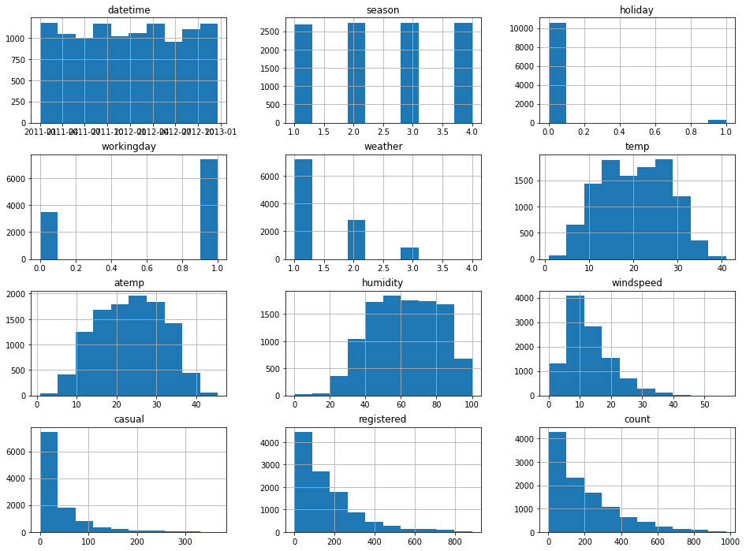

```python
# Create a histogram of all features to show the distribution of each one relative to the data. This is part of the exploritory data analysis
train.hist(figsize=(16,12))
```

```python
# create a new feature
train['year'] = train['datetime'].dt.year
train['month'] = train['datetime'].dt.month
train['day'] = train['datetime'].dt.day
train['hour'] = train['datetime'].dt.hour
```

```python
test['year'] = test['datetime'].dt.year
test['month'] = test['datetime'].dt.month
test['day'] = test['datetime'].dt.day
test['hour'] = test['datetime'].dt.hour
```

## Make category types for these so models know they are not just numbers

- AutoGluon originally sees these as ints, but in reality they are int representations of a category.
- Setting the dtype to category will classify these as categories in AutoGluon.

```python
cols_to_format = ['season','weather','holiday','workingday']

for item in cols_to_format:
    train[item] = train[item].astype('category')
    test[item] = test[item].astype('category')
```

```python
# View are new feature
train.dtypes
```

```
datetime      datetime64[ns]
season              category
holiday             category
workingday          category
weather             category
temp                 float64
atemp                float64
humidity               int64
windspeed            float64
casual                 int64
registered             int64
count                  int64
year                   int64
month                  int64
day                    int64
hour                   int64
dtype: object
```

```python
# View histogram of all features again now with the hour feature
test.dtypes
```

```
datetime      datetime64[ns]
season              category
holiday             category
workingday          category
weather             category
temp                 float64
atemp                float64
humidity               int64
windspeed            float64
year                   int64
month                  int64
day                    int64
hour                   int64
dtype: object
```

```python
# View are new feature
train.head()
```

|  | datetime | season | holiday | workingday | weather | temp | atemp | humidity | windspeed | casual | registered | count | year | month | day | hour |
| --- | --- | --- | --- | --- | --- | --- | --- | --- | --- | --- | --- | --- | --- | --- | --- | --- |
| 0 | 2011-01-01 00:00:00 | 1 | 0 | 0 | 1 | 9.84 | 14.395 | 81 | 0.0 | 3 | 13 | 16 | 2011 | 1 | 1 | 0 |
| 1 | 2011-01-01 01:00:00 | 1 | 0 | 0 | 1 | 9.02 | 13.635 | 80 | 0.0 | 8 | 32 | 40 | 2011 | 1 | 1 | 1 |
| 2 | 2011-01-01 02:00:00 | 1 | 0 | 0 | 1 | 9.02 | 13.635 | 80 | 0.0 | 5 | 27 | 32 | 2011 | 1 | 1 | 2 |
| 3 | 2011-01-01 03:00:00 | 1 | 0 | 0 | 1 | 9.84 | 14.395 | 75 | 0.0 | 3 | 10 | 13 | 2011 | 1 | 1 | 3 |
| 4 | 2011-01-01 04:00:00 | 1 | 0 | 0 | 1 | 9.84 | 14.395 | 75 | 0.0 | 0 | 1 | 1 | 2011 | 1 | 1 | 4 |

```python
test.head()
```

|  | datetime | season | holiday | workingday | weather | temp | atemp | humidity | windspeed | year | month | day | hour |
| --- | --- | --- | --- | --- | --- | --- | --- | --- | --- | --- | --- | --- | --- |
| 0 | 2011-01-20 00:00:00 | 1 | 0 | 1 | 1 | 10.66 | 11.365 | 56 | 26.0027 | 2011 | 1 | 20 | 0 |
| 1 | 2011-01-20 01:00:00 | 1 | 0 | 1 | 1 | 10.66 | 13.635 | 56 | 0.0000 | 2011 | 1 | 20 | 1 |
| 2 | 2011-01-20 02:00:00 | 1 | 0 | 1 | 1 | 10.66 | 13.635 | 56 | 0.0000 | 2011 | 1 | 20 | 2 |
| 3 | 2011-01-20 03:00:00 | 1 | 0 | 1 | 1 | 10.66 | 12.880 | 56 | 11.0014 | 2011 | 1 | 20 | 3 |
| 4 | 2011-01-20 04:00:00 | 1 | 0 | 1 | 1 | 10.66 | 12.880 | 56 | 11.0014 | 2011 | 1 | 20 | 4 |

```
array([[<AxesSubplot:title={'center':'datetime'}>,
        <AxesSubplot:title={'center':'temp'}>,
        <AxesSubplot:title={'center':'atemp'}>],
       [<AxesSubplot:title={'center':'humidity'}>,
        <AxesSubplot:title={'center':'windspeed'}>,
        <AxesSubplot:title={'center':'casual'}>],
       [<AxesSubplot:title={'center':'registered'}>,
        <AxesSubplot:title={'center':'count'}>,
        <AxesSubplot:title={'center':'year'}>],
       [<AxesSubplot:title={'center':'month'}>,
        <AxesSubplot:title={'center':'day'}>,
        <AxesSubplot:title={'center':'hour'}>]], dtype=object)
```

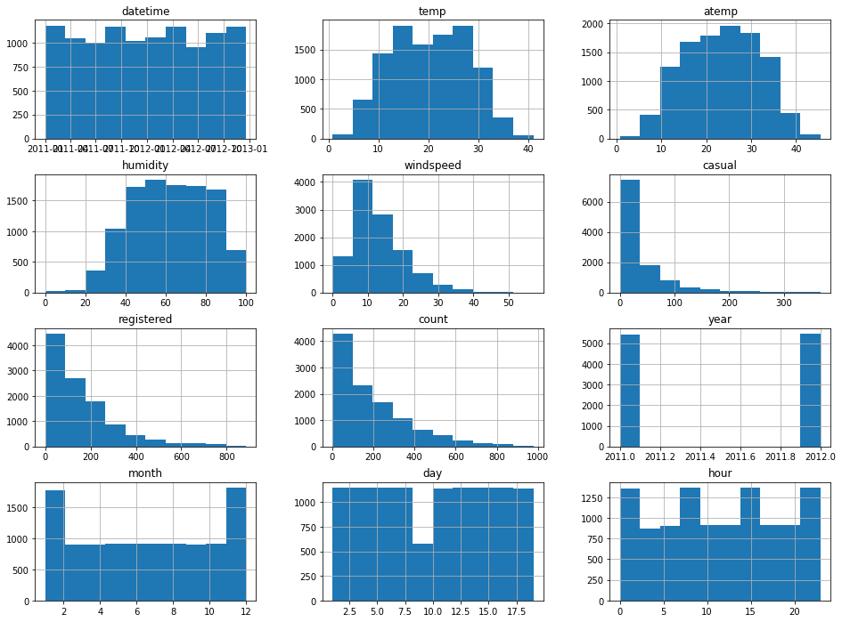

```python
# View histogram of all features again now with the hour feature
train.hist(figsize = (16,12))
```

```python
cols_to_use = [x for x in train.columns if x not in ['casual','registered','datetime']]
predictor_new_features = TabularPredictor(label = 'count', eval_metric = 'root_mean_squared_error').fit(train_data = train[cols_to_use],time_limit = 60*20, presets = "best_quality")
```

[output not shown]

```
[1000]	train_set's rmse: 30.8448	valid_set's rmse: 37.6336
[2000]	train_set's rmse: 25.828	valid_set's rmse: 36.1946
[3000]	train_set's rmse: 23.051	valid_set's rmse: 35.8247
[4000]	train_set's rmse: 21.035	valid_set's rmse: 35.7445
[5000]	train_set's rmse: 19.5137	valid_set's rmse: 35.7086
[6000]	train_set's rmse: 18.2362	valid_set's rmse: 35.8171
```

```
[1000]	train_set's rmse: 30.5612	valid_set's rmse: 41.6676
[2000]	train_set's rmse: 25.8336	valid_set's rmse: 39.54
[3000]	train_set's rmse: 23.117	valid_set's rmse: 38.8123
[4000]	train_set's rmse: 21.1553	valid_set's rmse: 38.4164
[5000]	train_set's rmse: 19.6323	valid_set's rmse: 38.1866
[6000]	train_set's rmse: 18.3473	valid_set's rmse: 38.0474
[7000]	train_set's rmse: 17.2846	valid_set's rmse: 37.9464
[8000]	train_set's rmse: 16.372	valid_set's rmse: 37.94
```

```
[1000]	train_set's rmse: 31.3639	valid_set's rmse: 35.7492
[2000]	train_set's rmse: 26.0704	valid_set's rmse: 34.4707
[3000]	train_set's rmse: 23.2701	valid_set's rmse: 34.2788
```

```
[1000]	train_set's rmse: 30.4546	valid_set's rmse: 41.3533
[2000]	train_set's rmse: 25.6382	valid_set's rmse: 39.8927
[3000]	train_set's rmse: 22.9751	valid_set's rmse: 39.2533
[4000]	train_set's rmse: 21.0503	valid_set's rmse: 38.8709
[5000]	train_set's rmse: 19.5613	valid_set's rmse: 38.5367
[6000]	train_set's rmse: 18.3487	valid_set's rmse: 38.305
[7000]	train_set's rmse: 17.2815	valid_set's rmse: 38.2156
[8000]	train_set's rmse: 16.3686	valid_set's rmse: 38.1137
[9000]	train_set's rmse: 15.5887	valid_set's rmse: 38.0142
[10000]	train_set's rmse: 14.8791	valid_set's rmse: 37.9498
```

```
[1000]	train_set's rmse: 30.9875	valid_set's rmse: 38.3401
[2000]	train_set's rmse: 25.7763	valid_set's rmse: 37.0177
[3000]	train_set's rmse: 23.002	valid_set's rmse: 36.7936
```

```
[1000]	train_set's rmse: 30.4742	valid_set's rmse: 41.682
[2000]	train_set's rmse: 25.6489	valid_set's rmse: 40.6328
[3000]	train_set's rmse: 22.8889	valid_set's rmse: 40.5213
```

```
[1000]	train_set's rmse: 31.098	valid_set's rmse: 38.972
[2000]	train_set's rmse: 26.1518	valid_set's rmse: 36.3259
[3000]	train_set's rmse: 23.3675	valid_set's rmse: 35.4266
[4000]	train_set's rmse: 21.3853	valid_set's rmse: 35.0473
[5000]	train_set's rmse: 19.8391	valid_set's rmse: 34.757
[6000]	train_set's rmse: 18.5142	valid_set's rmse: 34.7085
[7000]	train_set's rmse: 17.4016	valid_set's rmse: 34.6766
[8000]	train_set's rmse: 16.4616	valid_set's rmse: 34.6475
[9000]	train_set's rmse: 15.6291	valid_set's rmse: 34.7439
```

```
[1000]	train_set's rmse: 30.8466	valid_set's rmse: 39.2976
[2000]	train_set's rmse: 26.0207	valid_set's rmse: 37.8817
[3000]	train_set's rmse: 23.2835	valid_set's rmse: 37.4878
[4000]	train_set's rmse: 21.3296	valid_set's rmse: 37.2575
[5000]	train_set's rmse: 19.8148	valid_set's rmse: 37.1754
[6000]	train_set's rmse: 18.5534	valid_set's rmse: 37.1665
[7000]	train_set's rmse: 17.4554	valid_set's rmse: 37.1512
```

```
[1000]	train_set's rmse: 30.5918	valid_set's rmse: 40.7142
[2000]	train_set's rmse: 25.67	valid_set's rmse: 39.7503
[3000]	train_set's rmse: 22.9445	valid_set's rmse: 39.4996
[4000]	train_set's rmse: 20.9835	valid_set's rmse: 39.3705
```

```
[1000]	train_set's rmse: 31.1017	valid_set's rmse: 37.2527
[2000]	train_set's rmse: 26.25	valid_set's rmse: 35.3479
[3000]	train_set's rmse: 23.4971	valid_set's rmse: 34.9821
[4000]	train_set's rmse: 21.5279	valid_set's rmse: 34.7372
[5000]	train_set's rmse: 20.0153	valid_set's rmse: 34.5702
[6000]	train_set's rmse: 18.7423	valid_set's rmse: 34.4775
[7000]	train_set's rmse: 17.6617	valid_set's rmse: 34.4356
[8000]	train_set's rmse: 16.7156	valid_set's rmse: 34.4889
```

```
	-36.9063	 = Validation score   (root_mean_squared_error)
	90.06s	 = Training   runtime
	4.82s	 = Validation runtime
Fitting model: LightGBM_BAG_L1 ... Training model for up to 692.78s of the 1092.92s of remaining time.
```

```
[1000]	train_set's rmse: 22.1618	valid_set's rmse: 37.7812
```

```
[1000]	train_set's rmse: 22.2426	valid_set's rmse: 38.6453
[2000]	train_set's rmse: 16.4312	valid_set's rmse: 37.5551
[3000]	train_set's rmse: 12.8832	valid_set's rmse: 37.2872
```

```
[1000]	train_set's rmse: 22.3749	valid_set's rmse: 33.6347
```

```
[1000]	train_set's rmse: 21.8266	valid_set's rmse: 39.0645
[2000]	train_set's rmse: 16.2789	valid_set's rmse: 38.6651
[3000]	train_set's rmse: 12.8405	valid_set's rmse: 38.421
```

```
[1000]	train_set's rmse: 21.9076	valid_set's rmse: 38.1606
[2000]	train_set's rmse: 15.9937	valid_set's rmse: 37.7241
```

```
[1000]	train_set's rmse: 22.0474	valid_set's rmse: 40.9269
[2000]	train_set's rmse: 16.2441	valid_set's rmse: 40.1943
[3000]	train_set's rmse: 12.8116	valid_set's rmse: 40.0522
```

```
[1000]	train_set's rmse: 22.1679	valid_set's rmse: 36.2386
[2000]	train_set's rmse: 16.0504	valid_set's rmse: 35.5971
```

```
[1000]	train_set's rmse: 21.9424	valid_set's rmse: 37.3976
```

```
[1000]	train_set's rmse: 22.4023	valid_set's rmse: 41.5862
[2000]	train_set's rmse: 16.4244	valid_set's rmse: 41.1072
```

```
[1000]	train_set's rmse: 22.7887	valid_set's rmse: 37.2757
```

```
	-37.5491	 = Validation score   (root_mean_squared_error)
	32.29s	 = Training   runtime
	1.37s	 = Validation runtime
Fitting model: RandomForestMSE_BAG_L1 ... Training model for up to 654.79s of the 1054.93s of remaining time.
	-42.1946	 = Validation score   (root_mean_squared_error)
	7.85s	 = Training   runtime
	0.4s	 = Validation runtime
Fitting model: CatBoost_BAG_L1 ... Training model for up to 644.04s of the 1044.18s of remaining time.
	-37.8394	 = Validation score   (root_mean_squared_error)
	267.07s	 = Training   runtime
	0.14s	 = Validation runtime
Fitting model: ExtraTreesMSE_BAG_L1 ... Training model for up to 375.76s of the 775.9s of remaining time.
	-41.6115	 = Validation score   (root_mean_squared_error)
	3.74s	 = Training   runtime
	0.41s	 = Validation runtime
Fitting model: NeuralNetFastAI_BAG_L1 ... Training model for up to 369.08s of the 769.22s of remaining time.
	-46.5835	 = Validation score   (root_mean_squared_error)
	151.61s	 = Training   runtime
	0.38s	 = Validation runtime
Fitting model: XGBoost_BAG_L1 ... Training model for up to 216.21s of the 616.35s of remaining time.
	-39.0042	 = Validation score   (root_mean_squared_error)
	23.45s	 = Training   runtime
	0.29s	 = Validation runtime
Fitting model: NeuralNetMXNet_BAG_L1 ... Training model for up to 189.47s of the 589.61s of remaining time.
	Ran out of time, stopping training early. (Stopping on epoch 13)
	Ran out of time, stopping training early. (Stopping on epoch 13)
	Ran out of time, stopping training early. (Stopping on epoch 14)
	Ran out of time, stopping training early. (Stopping on epoch 14)
	Ran out of time, stopping training early. (Stopping on epoch 15)
	Ran out of time, stopping training early. (Stopping on epoch 18)
	Ran out of time, stopping training early. (Stopping on epoch 15)
	Ran out of time, stopping training early. (Stopping on epoch 18)
	Ran out of time, stopping training early. (Stopping on epoch 20)
	Ran out of time, stopping training early. (Stopping on epoch 21)
	-91.0485	 = Validation score   (root_mean_squared_error)
	180.42s	 = Training   runtime
	2.26s	 = Validation runtime
Fitting model: LightGBMLarge_BAG_L1 ... Training model for up to 6.22s of the 406.36s of remaining time.
	Ran out of time, early stopping on iteration 87. Best iteration is:
	[87]	train_set's rmse: 38.3557	valid_set's rmse: 45.6615
```

[output cut: 65 more lines]

```
	[35]	train_set's rmse: 68.2299	valid_set's rmse: 69.4369
	Ran out of time, early stopping on iteration 40. Best iteration is:
	[40]	train_set's rmse: 60.1537	valid_set's rmse: 63.5743
	Ran out of time, early stopping on iteration 41. Best iteration is:
	[41]	train_set's rmse: 58.721	valid_set's rmse: 60.782
	-69.097	 = Validation score   (root_mean_squared_error)
	4.73s	 = Training   runtime
	0.08s	 = Validation runtime
Completed 1/20 k-fold bagging repeats ...
Fitting model: WeightedEnsemble_L3 ... Training model for up to 360.0s of the -0.14s of remaining time.
	-35.5748	 = Validation score   (root_mean_squared_error)
	0.46s	 = Training   runtime
	0.0s	 = Validation runtime
AutoGluon training complete, total runtime = 1200.81s ...
TabularPredictor saved. To load, use: predictor = TabularPredictor.load("AutogluonModels/ag-20220223_071609/")
```

```python
predictor_new_features.fit_summary()
```

```
*** Summary of fit() ***
Estimated performance of each model:
                     model   score_val  pred_time_val     fit_time  pred_time_val_marginal  fit_time_marginal  stack_level  can_infer  fit_order
0      WeightedEnsemble_L3  -35.574796      12.102902  1004.088957                0.000744           0.460439            3       True         21
1      WeightedEnsemble_L2  -35.787620       6.732066   397.785163                0.000701           0.518136            2       True         11
2          CatBoost_BAG_L2  -36.005678      10.545821   811.666568                0.067616          55.108727            2       True         15
3   NeuralNetFastAI_BAG_L2  -36.080109      10.880197   892.206582                0.401992         135.648741            2       True         17
4          LightGBM_BAG_L2  -36.108540      10.574986   763.931176                0.096780           7.373335            2       True         13
5     ExtraTreesMSE_BAG_L2  -36.108892      10.938507   763.714929                0.460302           7.157088            2       True         16
6           XGBoost_BAG_L2  -36.356481      10.595077   769.238625                0.116872          12.680784            2       True         18
7   RandomForestMSE_BAG_L2  -36.382216      10.958597   785.659842                0.480392          29.102002            2       True         14
8        LightGBMXT_BAG_L2  -36.774698      10.641845   765.624336                0.163640           9.066496            2       True         12
9        LightGBMXT_BAG_L1  -36.906275       4.820359    90.061207                4.820359          90.061207            1       True          3
10         LightGBM_BAG_L1  -37.549108       1.366446    32.290527                1.366446          32.290527            1       True          4
11         CatBoost_BAG_L1  -37.839396       0.142766   267.067448                0.142766         267.067448            1       True          6
12   NeuralNetMXNet_BAG_L2  -38.043881      12.892857   886.769580                2.414652         130.211740            2       True         19
13          XGBoost_BAG_L1  -39.004179       0.287070    23.450811                0.287070          23.450811            1       True          9
14    ExtraTreesMSE_BAG_L1  -41.611451       0.408016     3.740327                0.408016           3.740327            1       True          7
15  RandomForestMSE_BAG_L1  -42.194610       0.401794     7.847845                0.401794           7.847845            1       True          5
16  NeuralNetFastAI_BAG_L1  -46.583459       0.380406   151.614588                0.380406         151.614588            1       True          8
17    LightGBMLarge_BAG_L2  -69.096954      10.559345   761.283976                0.081140           4.726135            2       True         20
18   NeuralNetMXNet_BAG_L1  -91.048512       2.263250   180.417800                2.263250         180.417800            1       True         10
19   KNeighborsDist_BAG_L1 -119.372602       0.204040     0.022754                0.204040           0.022754            1       True          2
20   KNeighborsUnif_BAG_L1 -123.921631       0.204057     0.044533                0.204057           0.044533            1       True          1
Number of models trained: 21
Types of models trained:
{'StackerEnsembleModel_RF', 'StackerEnsembleModel_KNN', 'WeightedEnsembleModel', 'StackerEnsembleModel_XT', 'StackerEnsembleModel_CatBoost', 'StackerEnsembleModel_TabularNeuralNet', 'StackerEnsembleModel_LGB', 'StackerEnsembleModel_XGBoost', 'StackerEnsembleModel_NNFastAiTabular'}
Bagging used: True  (with 10 folds)
Multi-layer stack-ensembling used: True  (with 3 levels)
Feature Metadata (Processed):
(raw dtype, special dtypes):
('category', [])  : 2 | ['season', 'weather']
('float', [])     : 3 | ['temp', 'atemp', 'windspeed']
('int', [])       : 4 | ['humidity', 'month', 'day', 'hour']
('int', ['bool']) : 3 | ['holiday', 'workingday', 'year']
Plot summary of models saved to file: AutogluonModels/ag-20220223_071609/SummaryOfModels.html
*** End of fit() summary ***
```

[output not shown]

[output cut: 211 more lines]

[output not shown]

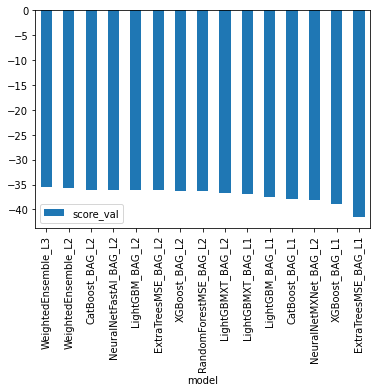

```python
# Remember to set all negative values to zero
predictor_new_features.leaderboard(silent = True).head(15).plot(kind = 'bar', x = 'model', y = 'score_val')
```

```python
predictions_new_features = predictor_new_features.predict(test)
predictions_new_features.head()
```

```
0    13.108663
1     4.344937
2     3.301445
3     3.901281
4     3.524323
Name: count, dtype: float32
```

```python
sum(predictions_new_features < 0)
```

```
2
```

```python
predictions_new_features[predictions_new_features < 0] =0
```

```python
submission_new_features = pd.read_csv('sampleSubmission.csv', parse_dates=['datetime'])
submission_new_features["count"] = predictions_new_features
submission_new_features.to_csv("submission_new_features.csv", index=False)
```

```python
!kaggle competitions submit -c bike-sharing-demand -f submission_new_features.csv -m "new features"
```

```
Successfully submitted to Bike Sharing Demand
```

```python
!kaggle competitions submissions -c bike-sharing-demand | tail -n +1 | head -n 6
```

```
fileName                     date                 description                                 status    publicScore  privateScore
---------------------------  -------------------  ------------------------------------------  --------  -----------  ------------
submission_new_features.csv  2022-02-23 07:43:34  new features                                complete  0.45956      0.45956
submission_new_features.csv  2022-02-23 07:15:37  new features                                complete  0.46085      0.46085
submission.csv               2022-02-23 06:47:45  first raw submission                        complete  1.39406      1.39406
submission_new_hpo_ALL.csv   2022-02-22 21:30:35  new features with hyperparameters           complete  0.55047      0.55047
tail: write error: Broken pipe
```

#### New Score of `0.45956`

## Step 6: Hyper parameter optimization

- There are many options for hyper parameter optimization.
- Options are to change the AutoGluon higher level parameters or the individual model hyperparameters.
- The hyperparameters of the models themselves that are in AutoGluon. Those need the `hyperparameter` and `hyperparameter_tune_kwargs` arguments.

```python
import autogluon.core as ag

nn_options = {  # specifies non-default hyperparameter values for neural network models
    'num_epochs': 10,  # number of training epochs (controls training time of NN models)
    'learning_rate': ag.space.Real(1e-4, 1e-2, default=5e-4, log=True),  # learning rate used in training (real-valued hyperparameter searched on log-scale)
    'activation': ag.space.Categorical('relu', 'softrelu', 'tanh'),  # activation function used in NN (categorical hyperparameter, default = first entry)
    'dropout_prob': ag.space.Real(0.0, 0.5, default=0.1),  # dropout probability (real-valued hyperparameter)
}

gbm_options = {  # specifies non-default hyperparameter values for lightGBM gradient boosted trees
    'num_boost_round': 100,  # number of boosting rounds (controls training time of GBM models)
    'num_leaves': ag.space.Int(lower=26, upper=66, default=36),  # number of leaves in trees (integer hyperparameter)
}


XGB_options = {
    'n_estimators': ag.space.Int(lower=1, upper=10),
    'eta': ag.space.Real(0.0, 0.35),
    'max_depth': ag.space.Int(lower=3, upper=6),
}



hyperparameters = {  # hyperparameters of each model type
                    'GBM': gbm_options,
                    'NN': nn_options,
                    'XGB': XGB_options
                  }

time_limit = 2*60  # train various models for ~2 min
#num_trials = 100  # try at most 5 different hyperparameter configurations for each type of model
search_strategy = 'auto'  # to tune hyperparameters using Bayesian optimization routine with a local scheduler

hyperparameter_tune_kwargs = {  # HPO is not performed unless hyperparameter_tune_kwargs is specified
    #'num_trials': num_trials,
    'scheduler' : 'local',
    'searcher': search_strategy,
}

predictor_new_hpo_NN = TabularPredictor(label = 'count', eval_metric = 'root_mean_squared_error').fit(
    train[cols_to_use], time_limit = 60*10,
    hyperparameters={'NN': nn_options}, hyperparameter_tune_kwargs=hyperparameter_tune_kwargs,presets = 'best_quality')


predictor_new_hpo_GBM = TabularPredictor(label = 'count', eval_metric = 'root_mean_squared_error').fit(
    train[cols_to_use], time_limit = 60*10,
    hyperparameters={'GBM': gbm_options}, hyperparameter_tune_kwargs=hyperparameter_tune_kwargs,presets = 'best_quality')


predictor_new_hpo_XGB = TabularPredictor(label = 'count', eval_metric = 'root_mean_squared_error').fit(
    train[cols_to_use], time_limit = 60*10,
    hyperparameters={'XGB': XGB_options}, hyperparameter_tune_kwargs=hyperparameter_tune_kwargs,presets = 'best_quality')


predictor_new_hpo_mixed = TabularPredictor(label = 'count', eval_metric = 'root_mean_squared_error').fit(
    train[cols_to_use], time_limit = 60*20,
    hyperparameters=hyperparameters, hyperparameter_tune_kwargs=hyperparameter_tune_kwargs,presets = 'best_quality')
```

[output not shown]

[output cut: 6317 more lines]

[output not shown]

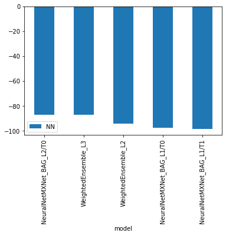

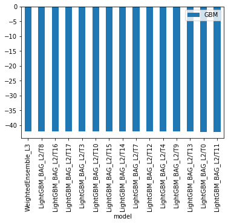

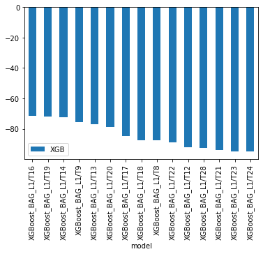

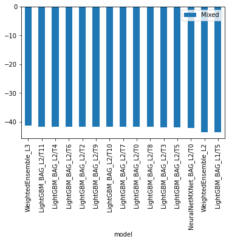

```python
predictor_new_hpo_NN.leaderboard(silent = True).head(15).plot(kind = 'bar', x = 'model', y = 'score_val', label = "NN")
predictor_new_hpo_GBM.leaderboard(silent = True).head(15).plot(kind = 'bar', x = 'model', y = 'score_val', label = "GBM")
predictor_new_hpo_XGB.leaderboard(silent = True).head(15).plot(kind = 'bar', x = 'model', y = 'score_val', label = "XGB")
predictor_new_hpo_mixed.leaderboard(silent = True).head(15).plot(kind = 'bar', x = 'model', y = 'score_val', label = "Mixed")
```

```python
# Remember to set all negative values to zero
predictions_new_features_NN = predictor_new_hpo_NN.predict(test)
predictions_new_features_GBM = predictor_new_hpo_GBM.predict(test)
predictions_new_features_XGB = predictor_new_hpo_XGB.predict(test)
predictions_new_features_ALL = predictor_new_hpo_mixed.predict(test)
```

```python
submission_new_hpo_NN = pd.read_csv('sampleSubmission.csv', parse_dates=['datetime'])
submission_new_hpo_GBM = pd.read_csv('sampleSubmission.csv', parse_dates=['datetime'])
submission_new_hpo_XGB = pd.read_csv('sampleSubmission.csv', parse_dates=['datetime'])
submission_new_hpo_ALL = pd.read_csv('sampleSubmission.csv', parse_dates=['datetime'])
```

```python
# Same submitting predictions
submission_new_hpo_NN["count"] = predictions_new_features_NN
submission_new_hpo_GBM["count"] = predictions_new_features_GBM
submission_new_hpo_XGB["count"] = predictions_new_features_XGB
submission_new_hpo_ALL["count"] = predictions_new_features_ALL
submission_new_hpo_NN.to_csv("submission_new_hpo_NN.csv", index=False)
submission_new_hpo_GBM.to_csv("submission_new_hpo_GBM.csv", index=False)
submission_new_hpo_XGB.to_csv("submission_new_hpo_XGB.csv", index=False)
submission_new_hpo_ALL.to_csv("submission_new_hpo_ALL.csv", index=False)
```

```python
!kaggle competitions submit -c bike-sharing-demand -f submission_new_hpo_NN.csv -m "new features with hyperparameters"
!kaggle competitions submit -c bike-sharing-demand -f submission_new_hpo_GBM.csv -m "new features with hyperparameters"
!kaggle competitions submit -c bike-sharing-demand -f submission_new_hpo_XGB.csv -m "new features with hyperparameters"
!kaggle competitions submit -c bike-sharing-demand -f submission_new_hpo_ALL.csv -m "new features with hyperparameters"
```

```
Successfully submitted to Bike Sharing Demand
```

```python
!kaggle competitions submissions -c bike-sharing-demand | tail -n +1 | head -n 6
```

```
fileName                     date                 description                                 status    publicScore  privateScore
---------------------------  -------------------  ------------------------------------------  --------  -----------  ------------
submission_new_hpo_ALL.csv   2022-02-23 08:24:16  new features with hyperparameters           complete  0.49406      0.49406
submission_new_hpo_XGB.csv   2022-02-23 08:24:14  new features with hyperparameters           complete  0.49621      0.49621
submission_new_hpo_GBM.csv   2022-02-23 08:24:12  new features with hyperparameters           complete  0.51693      0.51693
submission_new_hpo_NN.csv    2022-02-23 08:24:10  new features with hyperparameters           complete  0.69880      0.69880
tail: write error: Broken pipe
```